# packages

# load data

# function

# run function

[figure not shown]

Premier League 2020-2021: Matchday 1 (Sep 12 2020)

Minute

Team

Player

Result

Shot Map

Cumulative xG

Situation

Shot Type

Assist Player

Assist Action

2

Liverpool

Mohamed Salah

Blocked Shot

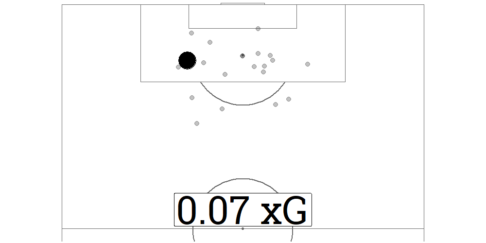

0.07

Open Play

Left Foot

Sadio Mané

Pass

3

Liverpool

Mohamed Salah

GOAL ⚽

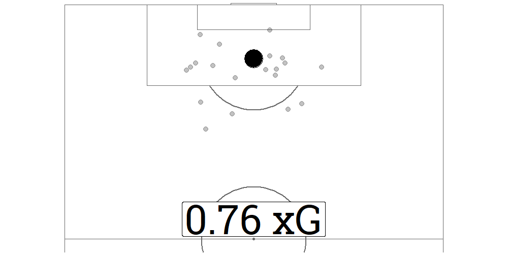

0.83

Penalty

Left Foot

Standard

6

Liverpool

Mohamed Salah

Blocked Shot

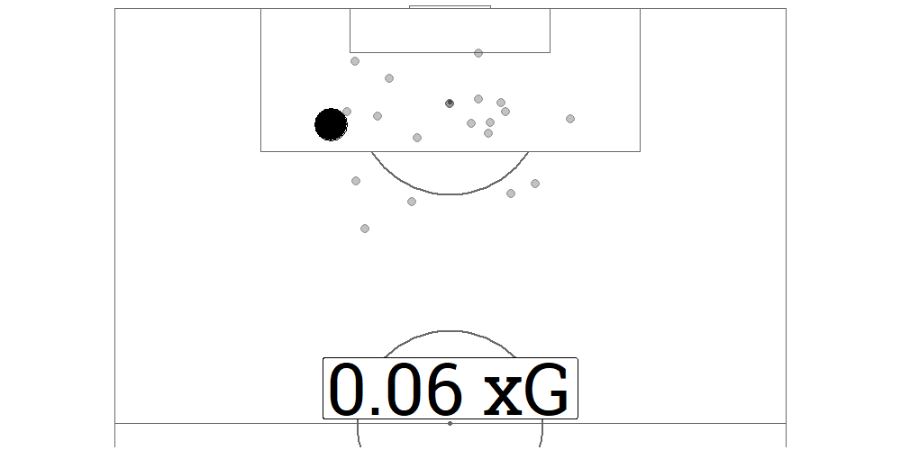

0.89

Open Play

Left Foot

Sadio Mané

Pass

11

Leeds

Jack Harrison

GOAL ⚽

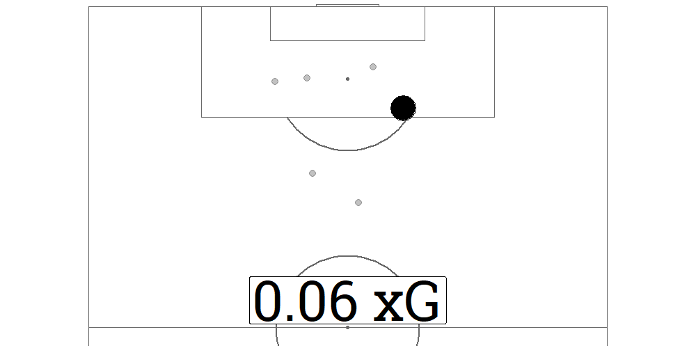

0.06

Open Play

Right Foot

Kalvin Phillips

Take On

19

Liverpool

Virgil van Dijk

GOAL ⚽

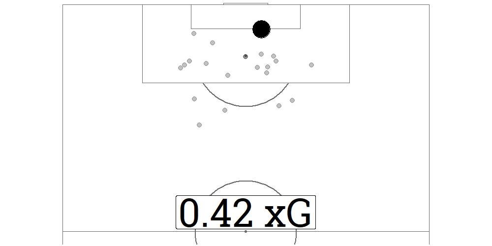

1.31

From Corner

Head

Andrew Robertson

Cross

24

Liverpool

Jordan Henderson

Saved Shot

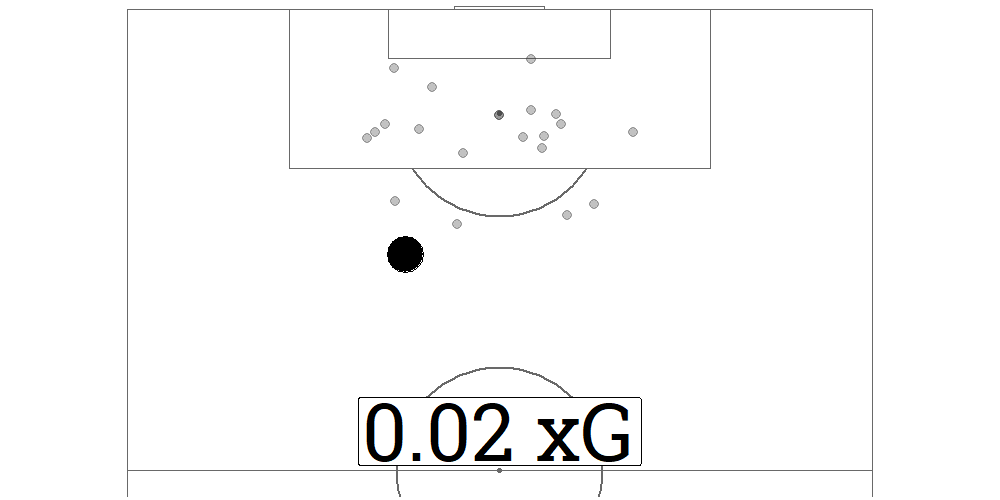

1.33

Open Play

Right Foot

28

Liverpool

Naby Keita

Blocked Shot

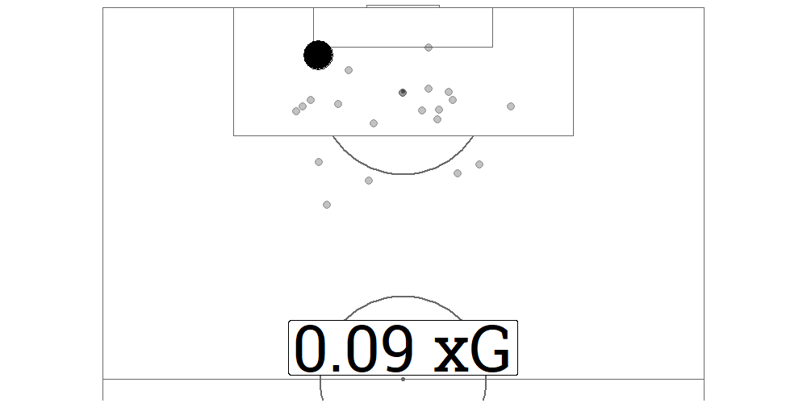

1.42

Open Play

Right Foot

29

Leeds

Patrick Bamford

GOAL ⚽

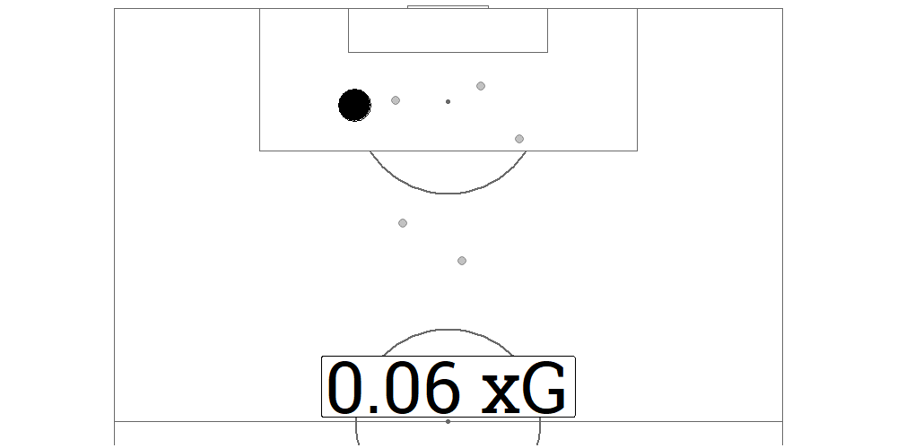

0.12

Open Play

Right Foot

32

Liverpool

Mohamed Salah

GOAL ⚽

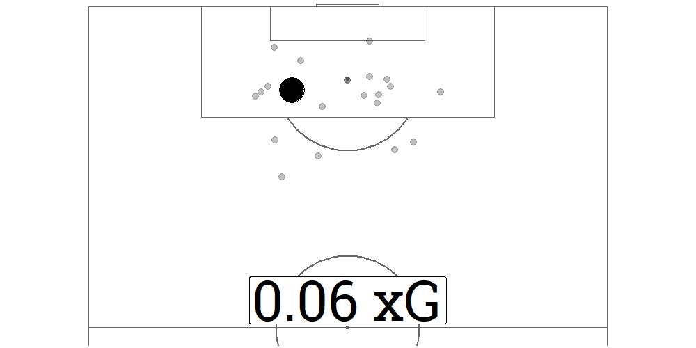

1.48

Set Piece

Left Foot

39

Liverpool

Sadio Mané

Blocked Shot

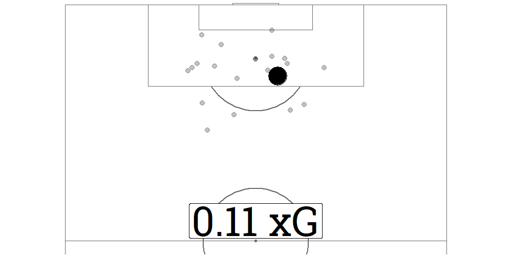

1.59

Open Play

Right Foot

Georginio Wijnaldum

Pass

39

Liverpool

Sadio Mané

Blocked Shot

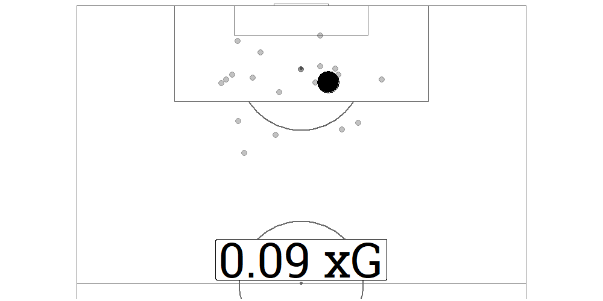

1.68

Open Play

Left Foot

Rebound

48

Liverpool

Georginio Wijnaldum

Saved Shot

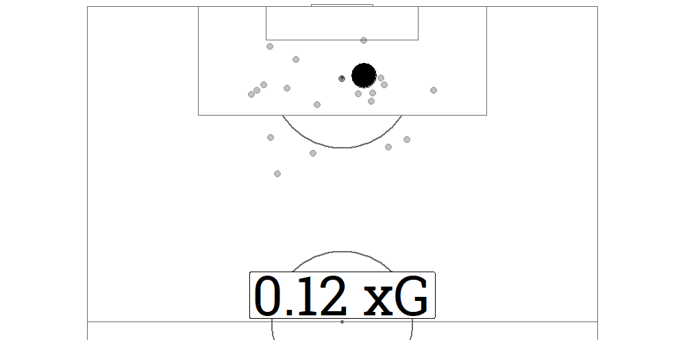

1.80

Open Play

Right Foot

Sadio Mané

Ball Touch

49

Leeds

Patrick Bamford

Blocked Shot

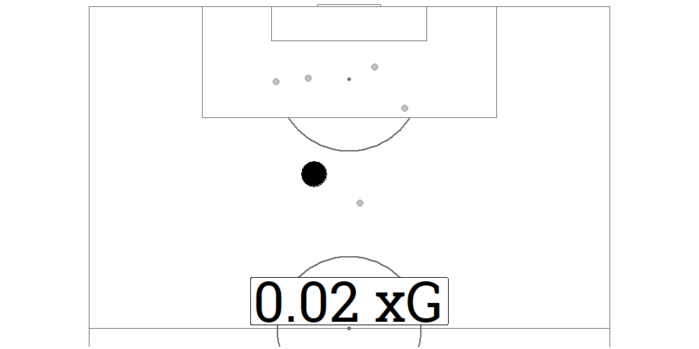

0.14

Open Play

Right Foot

Ball Recovery

52

Liverpool

Mohamed Salah

Blocked Shot

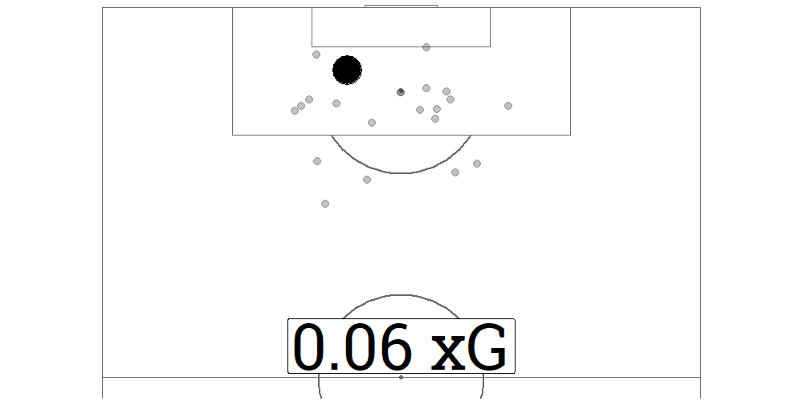

1.86

From Corner

Right Foot

Trent Alexander-Arnold

Cross

52

Liverpool

Virgil van Dijk

Missed Shot

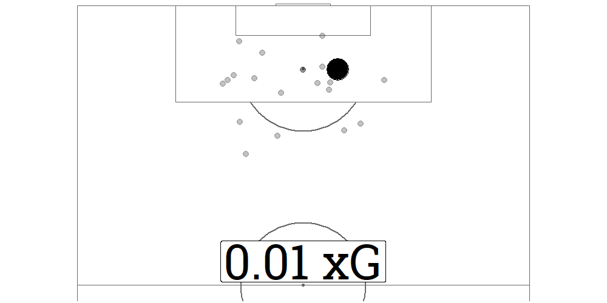

1.87

From Corner

Head

Trent Alexander-Arnold

Aerial

59

Liverpool

Mohamed Salah

Blocked Shot

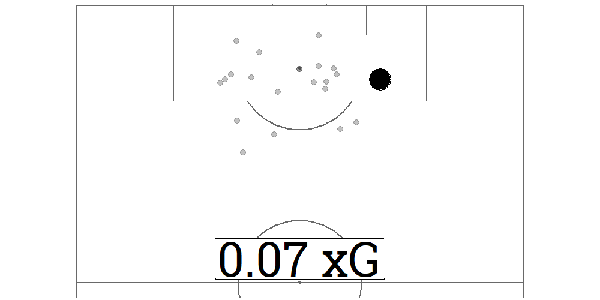

1.94

Open Play

Left Foot

Georginio Wijnaldum

Ball Recovery

61

Liverpool

Sadio Mané

Missed Shot

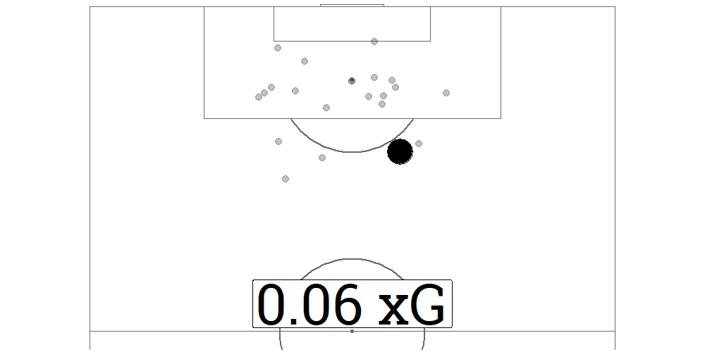

2.00

Open Play

Right Foot

Mohamed Salah

Pass

65

Leeds

Mateusz Klich

GOAL ⚽

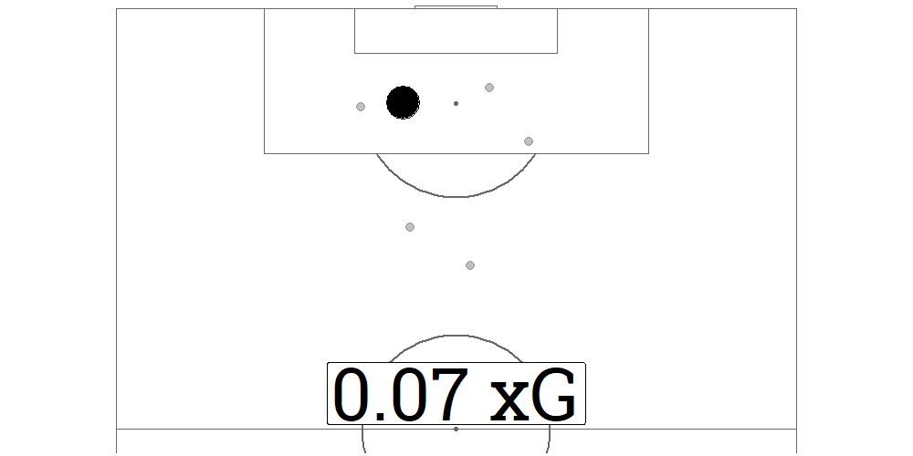

0.21

Open Play

Right Foot

Hélder Costa

Cross

67

Liverpool

Sadio Mané

Blocked Shot

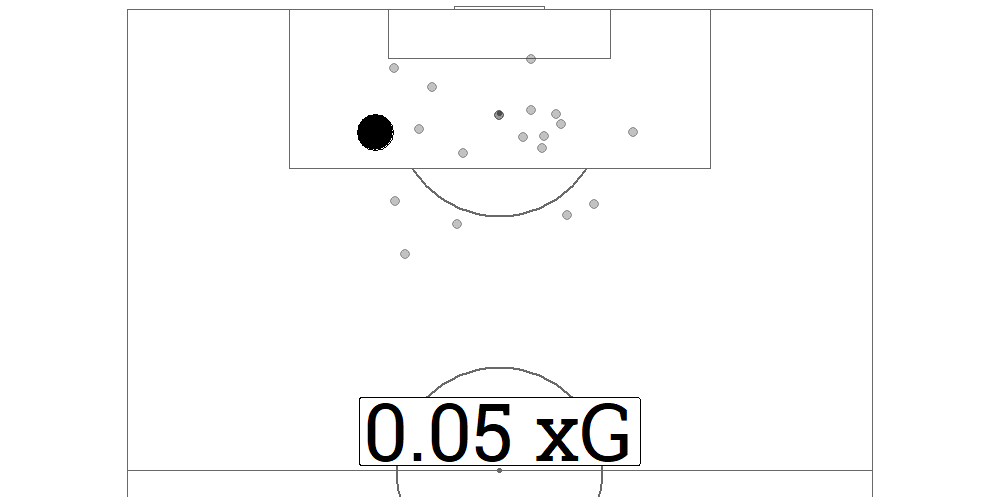

2.05

Open Play

Right Foot

Mohamed Salah

Pass

70

Liverpool

Mohamed Salah

Missed Shot

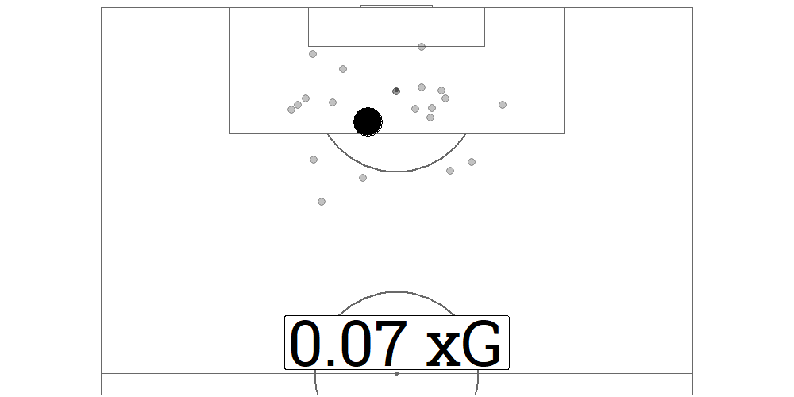

2.12

Open Play

Right Foot

70

Liverpool

Sadio Mané

Blocked Shot

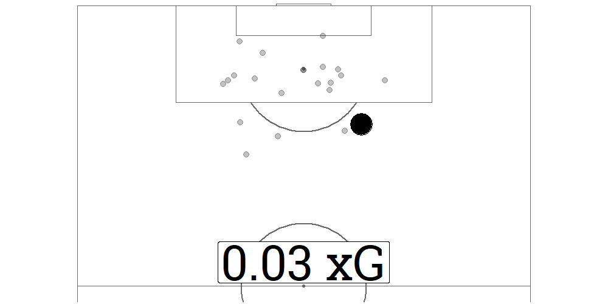

2.15

Open Play

Right Foot

Mohamed Salah

Take On

75

Leeds

Kalvin Phillips

Missed Shot

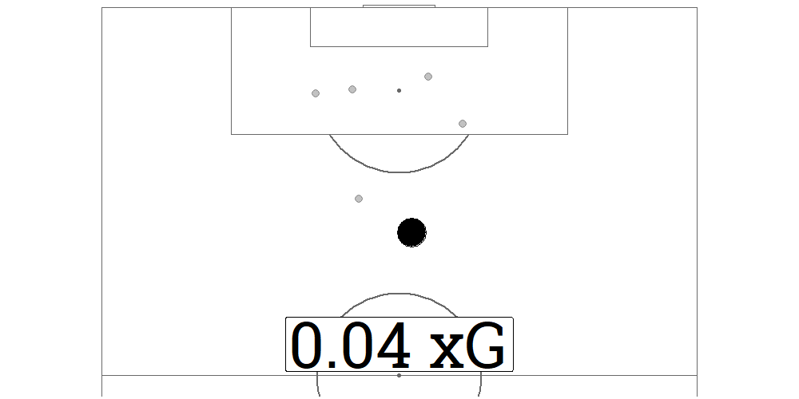

0.25

From Free Kick

Right Foot

Standard

77

Liverpool

Georginio Wijnaldum

Blocked Shot

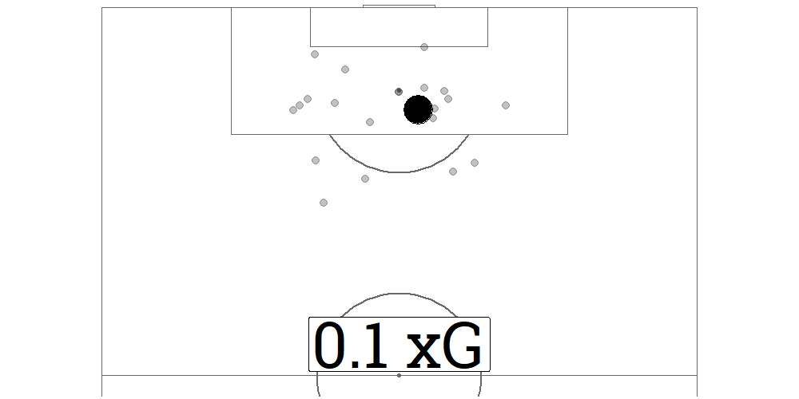

2.25

Open Play

Right Foot

Mohamed Salah

Pass

79

Liverpool

Mohamed Salah

Blocked Shot

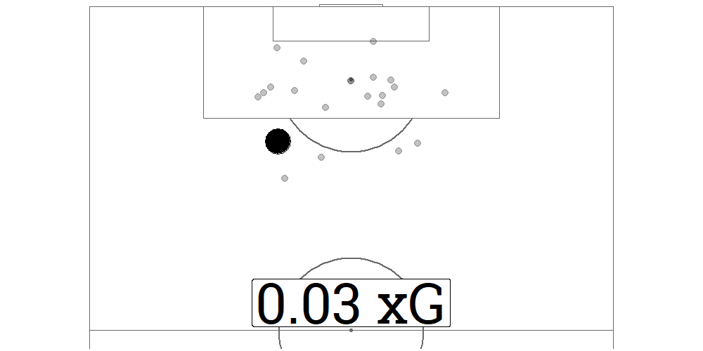

2.28

Open Play

Left Foot

Curtis Jones

Pass

84

Liverpool

Roberto Firmino

Blocked Shot

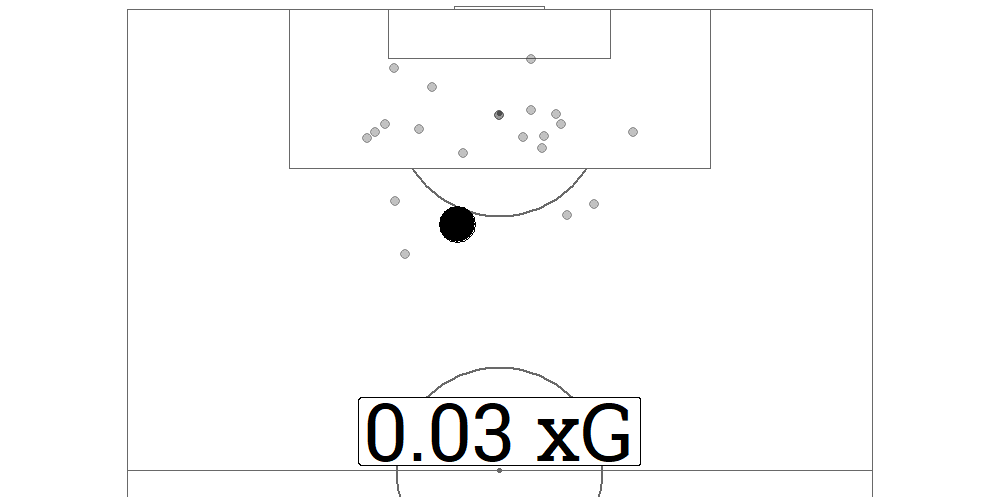

2.31

Open Play

Left Foot

86

Liverpool

Roberto Firmino

Blocked Shot

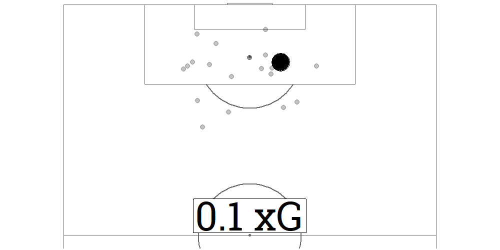

2.41

Open Play

Right Foot

Sadio Mané

Pass

87

Liverpool

Mohamed Salah

GOAL ⚽

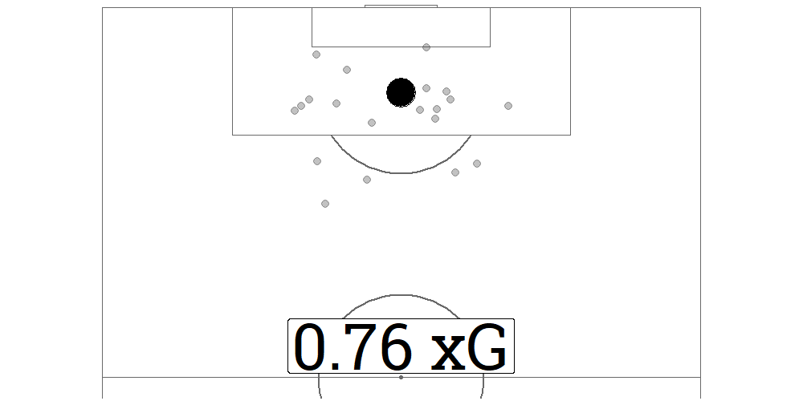

3.17

Penalty

Left Foot

Standard

90

Leeds

Robin Koch

Blocked Shot

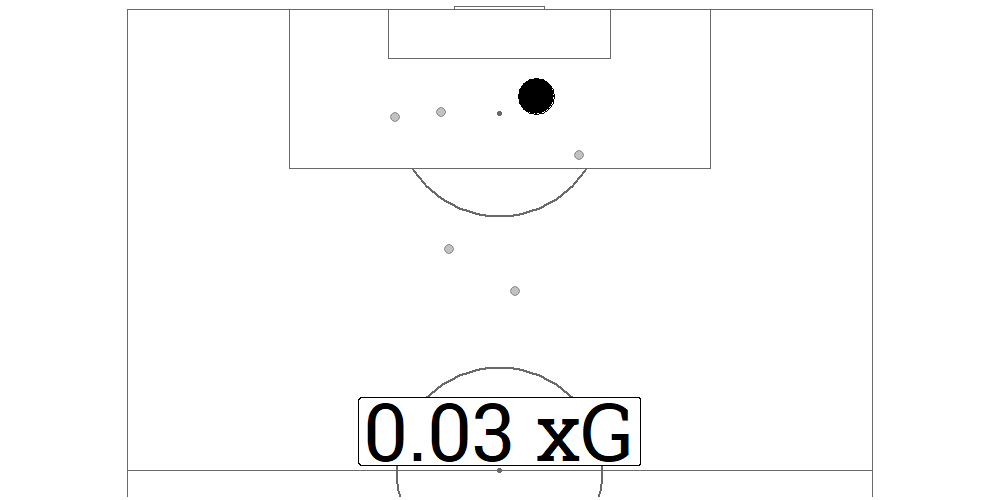

0.28

Open Play

Head

Kalvin Phillips

Aerial

**Table**: Ryo Nakagawara (**Twitter**: @R_by_Ryo) | **Data**: understat

# save